# Shaders applied to the screen

You may want to apply a shader to the whole screen to blur, stylize or even color correct.

Certain post-processing shaders, like glowing or depth of field, exist inside the *WorldEnvironment* node. However, you’ll have to create some effects yourself if you want to turn the screen into a pointilism drawing, or invert the colors for example.

[figure not shown]

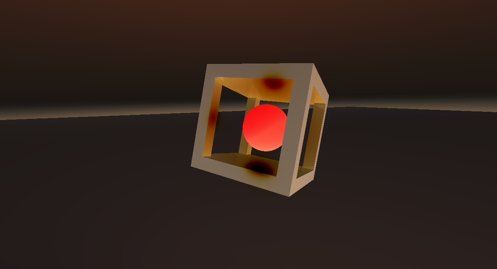

There are two methods of applying shaders to the whole screen. One works with color data, while the other works with 3D depth. Well explore using color data here. We’ll look into 3D depth in 3D post processing shaders.

## Viewports

*First, we have to talk about parallel universes.*

Grabbing the screen’s image data happens through a *Viewport* node. A viewport is a virtual screen onto which images are drawn. This view is separate from the main view and is not seen by the user. But we can display a viewport and then apply a shader to the node that displays it.

### ViewportContainer

The simplest method is the *ViewportContainer* node. Its job is to resize and show viewports.

1. Create a new User Interface scene.
2. Add a *ViewportContainer* node.
   - Enable its *Stretch* property and set its *Right* and *Bottom* anchor to 1 so it takes up the whole screen.
3. Add a *Viewport* node as a child of the container.
4. Instance a scene or add some objects as children of the *Viewport*.

For 3D scenes, you need to include a camera in every viewport. We will talk more about this in the 3D masking lesson.

Save your scene, then go to Scene -> Reload Saved Scene to force the viewport container to resize, and you should see your scene.

To apply a shader, select the *ViewportContainer*, add a new *ShaderMaterial* to its *Material* property, and assign a new shader. *ViewportContainers* are canvas items and, just like sprites, can take shaders too.

### ViewportTexture

The other method is the *TextureRect* that uses a *ViewportTexture*. *ViewportContainers* are easier to set up and less error prone, but *TextureRects* can be resized, stretched and distorted in ways containers cannot without separate shaders.

*Note: We still use a ViewportContainer, but only for its ability to resize. It’s optional since you could set the resolution manually in the* Size *property.*

1. Create a new User Interface scene.
2. Add a *ViewportContainer* node.
   1. Enable its *Stretch* property, set its *Right* and *Bottom* anchor to 1 so it takes up the whole screen.
   2. Set the *ViewportContainer*’s *Self Modulate* property’s alpha to 0 to hide it. (We can’t just set its visibility to 0, as we need Godot to update and render the contents.)
3. Add a *Viewport* node as a child of the container.
4. Instance a scene or add some objects as children of the *Viewport*.
5. Add a *TextureRect* as a child of the root of the scene.
6. In the *Texture* property, create a new *ViewportTexture* and select the *Viewport*.
   - Set the *TextureRect*’s *Right* and *Bottom* anchor to 1 so it takes up the whole screen.

Save your scene, then go to Scene -> Reload Saved Scene to force the viewport container and texture rectangle to resize, and you should see your scene.

*Hint: because of the way Godot renders in the background, your image may be upside down. You can use the* Flip V *property to fix this.*

If you want to change the size and position of the image - like making a small minimap in the corner - then you can control it like you would a regular *TextureRect* by enabling the *Expand* property and setting its *Stretch Mode* to *Scale* or *Keep Aspect*.

You can apply a new *ShaderMaterial* and a new shader to the *TextureRect* like you would with any canvas item.

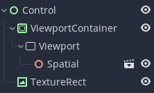

## Multiple passes

You may have wondered about it already, but what if the scene that’s under a *Viewport* is another *Viewport*? Or a *Viewport* of a *Viewport* of a *Viewport* of a Scene?

That is, in fact, how you would combine shaders into one final result! As long as they’re all sized, you can have any number of them. But it’s a good idea to split them up if you have a lot of them to avoid messy, unreadable scene trees.

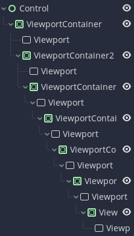

Regardless of which way you make your viewports, learning to juggle them is an important skill to master and we’ll revisit this topic in future tutorials that involve post-processing.